# Rising Stars Muay Thai: Data-Driven Insights & Strategic Roadmap

Juan De La Cruz

## Project Overview

**Data-Driven Growth Strategy for Rising Stars Muay Thai**

- Improve marketing performance and conversions
- Build analytics infrastructure
- Enable data-driven decision-making

## Data & Sources

- **Google Analytics 4 (Website):** User behavior, traffic, engagement
- **Eventbrite:** Ticket sales and attendance
- **Social Media:** Instagram & Facebook insights
- **Customer Data:** Demographics and behavior
- **Influencer Data:** Fighter engagement performance

## Managerial Problems

- No centralized website
- No analytics or tracking system
- No ability to measure ROI
- Limited customer insights
- Low membership conversion
- No influencer performance tracking

## Digital Transformation

**Important**

A fully functional website was developed and deployed using GitHub Pages.

- Google Analytics 4 integrated
- Real-time tracking implemented
- Website Traffic Analytics page created
- Data infrastructure established

## Target Audience

- Founder / Owner
- Marketing Team
- Event Operations Managers
- Sponsors and Partners

## Research Questions

- How can a website improve engagement and sales?
- What audience segments are most valuable?
- What content drives conversions?
- Where do users drop off?
- How do events impact memberships?
- Which fighters generate the highest ROI?

## Methods Used

- Descriptive Analytics
- Cluster Analysis
- Customer Journey Analysis
- Conversion Rate Analysis
- Logistic Regression
- A/B Testing
- Cross-Tabulation

## Website Analytics Implementation

**Tip**

Google Analytics 4 is actively tracking user behavior on the website.

- Tracks users, sessions, and page views
- Identifies high-performing content
- Measures engagement and interaction

## Traffic Forecast

- Website is newly launched → limited real data
- Created a **6-month forecast model**

Growth driven by: - Resume & LinkedIn sharing  
- Networking exposure  
- Repeat visitors

## Traffic Forecast Visualization

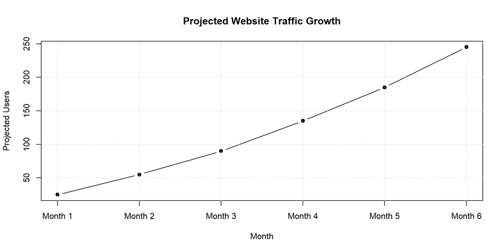

## Multi-Metric Forecast

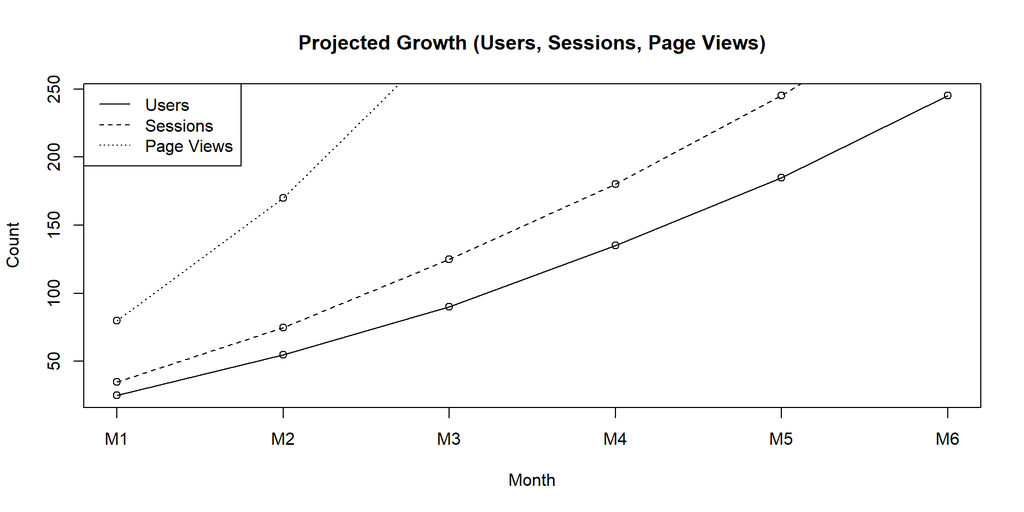

## Business Impact

- Increased ticket sales
- Higher membership conversions
- Improved marketing ROI
- Better audience targeting
- Data-driven decision-making
- Stronger sponsorship positioning

## Conclusion

- Website + GA4 = analytics foundation
- Forecasting enables proactive strategy
- Transition from intuition → data-driven growth